# HW2

### Please submit as an HTML or PDF file

Print your name (First Name Last Name) below

```python
Gahyun Lim
```

## 1. Prerequisites

- Install `openpyxl` package in PyCharm. (1')
- Import `pandas` and `matplotlib` packages. (1')
  - For `pandas`, rename it as `pd`.
  - For `matplotlib`, find its `pyplot` module and rename it as `plt`.

```python
* Take a snapshot and attach it below to show that you have `openpyxl` properly installed. (1')
```

[figure not shown]

[figure not shown]

```python
# Note: you do not need to explicitly import openpyxl because it is loaded in the backend once you import pandas.
```

## 2. Overview on the Dataset

Open `PTSD dataset.xlsx` in the "data" folder

- Read it as a pandas object called `ptsd_df`, choose the sheet named `main_dataset`. (1')
- Note: This is a clinical dataset to study the PTSD from my past collaboration. The PI, Dr. Boadie Dunlop has kindly agreed to share it with me for educational purposes. For more information, check the paper below.
  - [Effect of agreement between clinician-rated and patient-reported PTSD symptoms on intensive outpatient treatment outcomes](https://doi.org/10.1016/j.psychres.2024.116287)

```python
import matplotlib.pyplot as plt
import pandas as pd
ptsd_df = pd.read_csv('./PTSD dataset.csv')
ptsd_df.head()
```

|  | record_id | ptsdpresent_caps | caps_minuspcl | caps_minuspcl_code | caps_intake | pcl5_score_intake | pcl5month_score.baseline | pcl5week_score.completion | pcl5month_score.3_month_follow_up | mdd_code | ... | state_code | va_benefits_indicator | wwp_alumni_indicator | army | airforce | marines | navy | coastguard | nationalguard | reserve |
| --- | --- | --- | --- | --- | --- | --- | --- | --- | --- | --- | --- | --- | --- | --- | --- | --- | --- | --- | --- | --- | --- |
| 0 | 460 | 1 | -56 | 1 | 15 | 71 | 75.0 | 40.0 | NaN | 0 | ... | TX | Yes | No | 1.0 | 0.0 | 0.0 | 0.0 | 0.0 | 0.0 | 0.0 |
| 1 | 5942 | 1 | -49 | 1 | 23 | 72 | NaN | 52.0 | 29.0 | 0 | ... | GA | Yes | No | 0.0 | 1.0 | 0.0 | 0.0 | 0.0 | 0.0 | 0.0 |
| 2 | 5366 | 1 | -48 | 1 | 31 | 79 | 62.0 | 23.0 | NaN | 1 | ... | GA | N | N | 1.0 | 0.0 | 0.0 | 0.0 | 0.0 | 0.0 | 0.0 |
| 3 | 3480 | 1 | -47 | 1 | 31 | 78 | 76.0 | 72.0 | NaN | 0 | ... | GA | Yes | Yes | 1.0 | 0.0 | 0.0 | 0.0 | 0.0 | 0.0 | 0.0 |
| 4 | 1029 | 1 | -46 | 1 | 28 | 74 | 52.0 | 29.0 | 36.0 | 0 | ... | GA | Yes | No | 0.0 | 0.0 | 1.0 | 0.0 | 0.0 | 0.0 | 0.0 |

5 rows × 439 columns

```python
ptsd_df
```

|  | record_id | ptsdpresent_caps | caps_minuspcl | caps_minuspcl_code | caps_intake | pcl5_score_intake | pcl5month_score.baseline | pcl5week_score.completion | pcl5month_score.3_month_follow_up | mdd_code | ... | state_code | va_benefits_indicator | wwp_alumni_indicator | army | airforce | marines | navy | coastguard | nationalguard | reserve |
| --- | --- | --- | --- | --- | --- | --- | --- | --- | --- | --- | --- | --- | --- | --- | --- | --- | --- | --- | --- | --- | --- |
| 0 | 460 | 1 | -56 | 1 | 15 | 71 | 75.0 | 40.0 | NaN | 0 | ... | TX | Yes | No | 1.0 | 0.0 | 0.0 | 0.0 | 0.0 | 0.0 | 0.0 |
| 1 | 5942 | 1 | -49 | 1 | 23 | 72 | NaN | 52.0 | 29.0 | 0 | ... | GA | Yes | No | 0.0 | 1.0 | 0.0 | 0.0 | 0.0 | 0.0 | 0.0 |
| 2 | 5366 | 1 | -48 | 1 | 31 | 79 | 62.0 | 23.0 | NaN | 1 | ... | GA | N | N | 1.0 | 0.0 | 0.0 | 0.0 | 0.0 | 0.0 | 0.0 |
| 3 | 3480 | 1 | -47 | 1 | 31 | 78 | 76.0 | 72.0 | NaN | 0 | ... | GA | Yes | Yes | 1.0 | 0.0 | 0.0 | 0.0 | 0.0 | 0.0 | 0.0 |
| 4 | 1029 | 1 | -46 | 1 | 28 | 74 | 52.0 | 29.0 | 36.0 | 0 | ... | GA | Yes | No | 0.0 | 0.0 | 1.0 | 0.0 | 0.0 | 0.0 | 0.0 |
| ... | ... | ... | ... | ... | ... | ... | ... | ... | ... | ... | ... | ... | ... | ... | ... | ... | ... | ... | ... | ... | ... |
| 478 | 1922 | 1 | 13 | 3 | 44 | 31 | 34.0 | 25.0 | 27.0 | 1 | ... | NJ | No | No | 0.0 | 1.0 | 0.0 | 0.0 | 0.0 | 0.0 | 0.0 |
| 479 | 2427 | 1 | 21 | 3 | 42 | 21 | 45.0 | 13.0 | 16.0 | 0 | ... | OK | No | No | 0.0 | 1.0 | 0.0 | 0.0 | 0.0 | 0.0 | 0.0 |
| 480 | 179 | 1 | 21 | 3 | 38 | 17 | 17.0 | NaN | NaN | 1 | ... | GA | Yes | No | 0.0 | 0.0 | 1.0 | 0.0 | 0.0 | 0.0 | 0.0 |
| 481 | 3533 | 1 | 24 | 3 | 38 | 14 | 35.0 | 25.0 | 15.0 | 0 | ... | CA | Yes | Yes | 1.0 | 0.0 | 0.0 | 0.0 | 0.0 | 0.0 | 1.0 |
| 482 | 3021 | 1 | 30 | 3 | 42 | 12 | 66.0 | 74.0 | 11.0 | 1 | ... | NC | Yes | Yes | 1.0 | 0.0 | 0.0 | 0.0 | 0.0 | 0.0 | 0.0 |

483 rows × 439 columns

- Find the variable names of the dataset, assign it to a variable name `ptsd_col_name`. (1')
- Print out the type of the variable `ptsd_col_name`. (1')
- Convert it to a list without changing the variable name and confirm the type as a list. (2')
- Print out `ptsd_col_name`. (1')
- Find and print out the first item of the `ptsd_col_name`. (1') Answer: record_id
- Find and print out the index corresponding to the variable `pcl5_score_intake`. (1') Answer: 5

```python
ptsd_col_name = ptsd_df.columns
print(type(ptsd_col_name))
```

```
<class 'pandas.core.indexes.base.Index'>
```

```python
ptsd_col_name = ptsd_col_name.tolist()
print(type(ptsd_col_name))
```

```
<class 'list'>
```

```python
print(ptsd_col_name)
print(ptsd_col_name.index('pcl5_score_intake'))
```

```
['record_id', 'ptsdpresent_caps', 'caps_minuspcl', 'caps_minuspcl_code', 'caps_intake', 'pcl5_score_intake', 'pcl5month_score.baseline', 'pcl5week_score.completion', 'pcl5month_score.3_month_follow_up', 'mdd_code', 'ctq_total_score', 'sexual_trauma', 'sud_code', 'phq9_score_intake', 'phq9_score.base…
5
```

## 3. Descriptive Statistics and Visualization

- Compute and print out descriptive statistics of `pcl5_score_intake`.
  - Directly type the name such as `df["col_name"]`. (1')
  - Use `ptsd_col_name` with an index to extract the column `pcl5_score_intake`. (1')

```python
ptsd_df["pcl5_score_intake"].describe()
```

```
count    483.000000
mean      53.612836
std       14.165925
min        8.000000
25%       44.000000
50%       54.000000
75%       64.000000
max       80.000000
Name: pcl5_score_intake, dtype: float64
```

```python
ptsd_df[ptsd_col_name[5]].describe()
```

```
count    483.000000
mean      53.612836
std       14.165925
min        8.000000
25%       44.000000
50%       54.000000
75%       64.000000
max       80.000000
Name: pcl5_score_intake, dtype: float64
```

- Generate a scatter plot that shows `pcl5_score_intake` in the y-axis and `age_iop` in the x-axis.
  - `pcl5_score_intake` refers to "PCL5 Score at Intake", while `age_iop` refers to "Age".
  - Extract columns to create two variables named `age` and `pcl5_score_intake`, respectively. (1')
  - Generate the scatter plot. (1')
  - Label both x and y axes properly and the title as "Scatter Plot". (1')
  - Show the plot. (1')

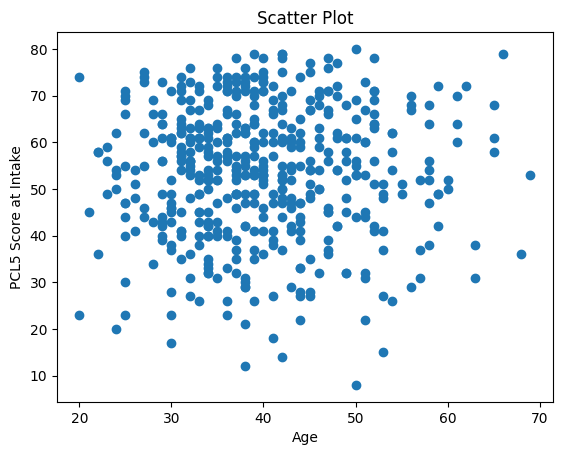

```python
age = ptsd_df["age_iop"]
pcl5_score_intake = ptsd_df["pcl5_score_intake"]

plt.scatter(x=age, y=pcl5_score_intake)
plt.xlabel("Age")
plt.ylabel("PCL5 Score at Intake")
plt.title("Scatter Plot")
plt.show()
```

- Provide a frequency table of `gender_code`. (1')

```python
table = pd.crosstab(index = ptsd_df['gender_code'], columns = "count")
table
```

| col_0 gender_code | count |
| --- | --- |
| 1 | 290 |
| 2 | 193 |

- Provide a contingency table between `gender_code` and `race_code`. (1')

```python
contingency_table = pd.crosstab(ptsd_df["gender_code"], ptsd_df["race_code"])
print(contingency_table)
```

```
race_code      1   2  3  4  5   6
gender_code
1            194  58  4  0  5  29
2             76  86  6  3  6  16
```

Save it as `HW2.html` or `HW2.pdf` and upload it to Canvas.